# Homework 1 (712): Predict the 2018 US Senate Midterm Elections

#### Preface

- **This homework is due Monday November 5, 2018 at 11:59 PM**.
- When you have completed the assignment, knit the R Markdown, commit your changes and push to GitHub.
- If you do not include axis labels and plot titles, then points will be deducted.
- If you do not include prose/text after the sections titled “Add a summary of your findings here”, then points will be deducted.
- As as reminder, you can use up to two late days (if available) on this assignment without any penalty (see [Syllabus](https://jhu-advdatasci.github.io/2018/syllabus.html) on course website for more details on Late Day Policy).
- You are welcome and encouraged to discuss homework problems with others in order to better understand it, but the work you turn in must be your own. You must write your own code, data analyses, and communicate and explain the results in your own words and with your own visualizations. **All students turning in plagiarized solutions will be reported to Office of Academic Integrity, and will fail the assignment**.

## Motivation

The goal of this homework assignment is to use US opinion polling data (any any other sources of data) for the current 2018 Senate Midterm Elections and predict the results in each state.

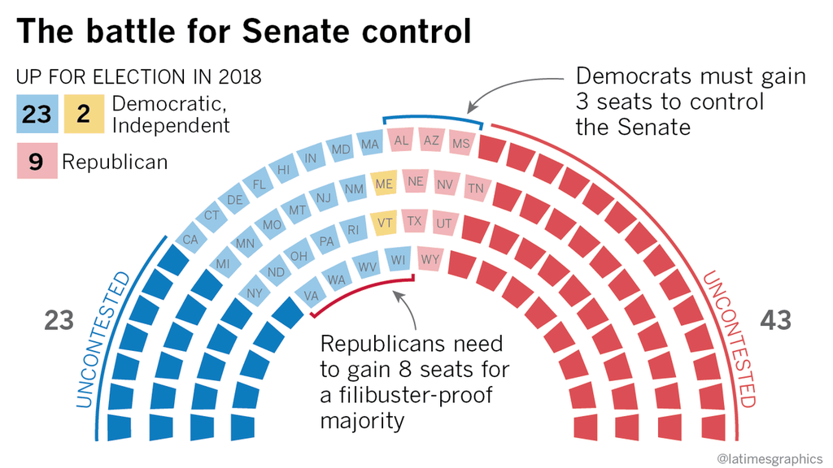

[image source](http://www.latimes.com/politics/la-na-pol-trump-2018-senate-20170217-story.html)

We will have three competitions with the terms for scoring entries described below (see Problem 3). The winner of each competition will win an Amazon gift card!

The three competitions are the following:

1. Predict the number of Republican senators. You may provide an interval. Smallest interval that includes the election day result wins. (Problem 3.1)
2. Predict the republican-democrat (R-D) difference in each state. The predictions that minimize the residual sum of squares between predicted and observed differences wins. (Problem 3.2)
3. Report a confidence interval for the R-D difference in each state. If the election day result falls outside your confidence interval in more than two states you are eliminated. For those surviving this cutoff, we will add up the size of all confidence intervals and sum. The smallest total length of confidence interval wins. (Problem 3.3)

To submit your predictions, we will post a link on Slack to a Google Form.

### Data

Some data you will find useful are:

1. US Opinion poll data from:
   - [RealClear Politics](https://www.realclearpolitics.com/epolls/2018/senate/2018_elections_senate_map.html) – contains current senate polling data
   - [Huffington Post Pollster API](https://elections.huffingtonpost.com/pollster/api/v2) – contains historical polling data
2. Summary table from FiveThirtyEight used in their Senate Model (data available in a [CSV](https://projects.fivethirtyeight.com/congress-model-2018/senate_seat_forecast.csv) format).